# Stacy Irwin’s Portfolio

13 November 2021

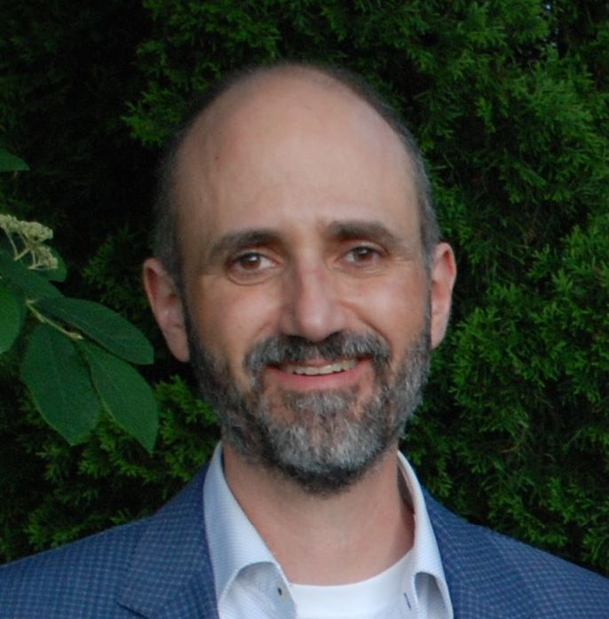

He/Him

I’m a former nuclear submariner who is transitioning to data science. I have over ten years’ experience in programming and using statistical analysis to solve business problems.

This page lists several of my projects that are related to coding, statistics, and data science. Feel free to send me a message on [LinkedIn](https://www.linkedin.com) if you would like to chat about any of these projects.

## Quick Links

- [LinkedIn Profile](https://www.linkedin.com/in/stacyirwinseattle/)
- Résumé

## Project List

#### Masters Degree Projects

These projects were completed to meet the requirements of the Masters of Information and Data Science (MIDS) Program at the University of California Berkeley.

- [Article-Level Fake News Detection With BERT-Derived Natural Language Processing Architectures](https://github.com/irwinsnet/w266_project)
- [Transformers for Expansion of Sparse Indexes in Information Retrieval](https://github.com/sirwin31/neural_info_retrieval)

#### Teaching Python

An online Python course created for robotics students at Issaquah High School in Washington state.

- [Python Tutorial on Google Colab](https://colab.research.google.com/github/irs1318dev/pyclass_frc/blob/master/index.ipynb)
- [Python Tutorial Github Repo](https://github.com/irs1318dev/pyclass_frc)

#### Projects Related to [FIRST](https://www.firstinspires.org)

These projects related to my work with the robotics team at Issaquah High School.

- [FRC Robot Path Viewer](http://pviewer.herokuapp.com)
- [R Package for Downloading Robotics Competition Data](https://github.com/irwinsnet/firstapiR)
- [Analytics Application for Robotics Competitions](https://github.com/irs1318dev/scouting2020)

#### Other Projects

- Probabilistic Robotics

## Project Descriptions

### Article-Level Fake News Detection With BERT-Derived Natural Language Processing Architectures

I and one other student collaborated on this project for Berkeley’s W266 course in natural language processing (NLP). [Here is a link to the project repo.](https://github.com/irwinsnet/w266_project)

##### Research Question

Due to BERT’s sequence length limit of 512 tokens, many article classifiers ignore all portions of an article that exceed this limit. We were curious if the [Longformer model](https://arxiv.org/abs/2004.05150), with it’s 4096 token limit, would perform better on classifying articles as either fake or real news compared to a BERT model with a 512 token sequence limit. Our dataset, the FakeNewsNet corpus, consisted of about 24,000 fake and real articles. Approximately one thousand of the articles were on political topics, while the rest focused on celebrity news.

##### What we Learned

The memory requirements of typical attention mechanism used by BERT and other transformers are proportional to the square of the sequence length. Longformer uses a sparse attention mechanism with memory requirements that scale linearly with sequence length.

Nevertheless, Longformer’s memory requirements are still significant, and we had difficulty successfully training it with the Google Cloud Platform resources that fell within our budget. Perhaps due to the small training batch size and the relatively small dataset, we were unable to get Longformer to outperform a simple model based on [DistilBERT](https://arxiv.org/abs/1910.01108), (which truncated all articles at 512 tokens).

Our best performing model achieved an F1 score of about 0.707. We used a DistilBERT model to classify articles as either celebrity or political news, then used one of two [RoBERTa](https://arxiv.org/abs/1907.11692) models to classify the articles as real or fake.

With respect to learning how to implement transformer models and use Pytorch, this was a useful project.

### Transformers for Expansion of Sparse Indexes in Information Retrieval

Berkeley MIDS students complete a final group project before receiving their diplomas. I worked with three other students on a project that applies recent advancements in NLP to the field of information retrieval. The project was inspired by work completed by [Zhuyun Dai and Jamie Callan at Carnegie Mellon University](https://dl.acm.org/doi/10.1145/3366423.3380258) and [Rodrigo Nogueira and Jimmy Lin at University of Waterloo.](https://cs.uwaterloo.ca/~jimmylin/publications/Nogueira_Lin_2019_docTTTTTquery-v2.pdf)

##### Research Question

In [Context-Aware Document Term Weighting for Ad-Hoc Search](https://par.nsf.gov/servlets/purl/10170033) Dai and Callan describe a BERT-based model for generating document retrieval indexes. Traditional indexes contain document term weights based on term frequency (how many times a term occurs within a document) and inverse document frequency (how common or rare a term is within a document collection). These techniques are often referred to as TF-IDF. Dai and Callan built a model that analyzes how terms are used within a text passage and generates weights based on the term’s importance. An advantaged of Dai and Callan’s approach is that the machine learning models are used offline, when the index is built. Processing a query only requires index look-ups, which are efficient compared to using machine learning models. A disadvantage is that for a given document, the index only contains terms that occur in the document. If a query uses synonyms or other related terms that do not occur in a specific document, the system will not return the document, even though it may be relevant to the users information needs. This issue is called vocabulary mismatch.

We were interested in techniques that retain the evaluation of the importance of a term within a sentence, but that also address vocabulary mismatch. Nogueira and Lin had developed a process for creating document indexes using Google’s T5 network with a machine translation architecture. Their method is capable of terms to an index that are relevant to the document but that do not appear in the document. However they used TF-IDF style algorithms to build indexes from the output of the T5 model.

##### What we Learned

[We attempted to combine Dai & Callan’s and Nogueira and Lin’s techniques for building sparse indexes for document retrieval.](https://github.com/sirwin31/neural_info_retrieval) Our objective was to have a model that would both evaluate term importance and address vocabulary mismatch. In the end, our combined method was no better than either of the individual models.

### Teaching Python

I am a mentor for a [FIRST Robotics Competition (FRC)](https://www.firstinspires.org/robotics/frc/what-is-first-robotics-competition) team and I started teaching the students Python a few years ago. I couldn’t find any online teaching materials that precisely met our requirements, so I created our own course. All information is presented via Jupyter notebooks.

- [Python Tutorial on Google Colab](https://colab.research.google.com/github/irs1318dev/pyclass_frc/blob/master/index.ipynb)
- [Python Tutorial Github Repo](https://github.com/irs1318dev/pyclass_frc)

The course is taught from a data-analysis perspective. We want the students to understand that coding skills are useful for everyone, not just computer science majors and software engineers.

### FRC Robot Path Viewer

The FRC Path Viewer is a visualization tool for the FIRST Robotics Competition (FRC) position tracking data that is generated during competitions. You can [try out the viewer here.](http://pviewer.herokuapp.com) The code is availabe on Github at https://github.com/irwinsnet/frc_path_viewer.

### R Package for Downloading Robotics Data, firstapiR

[FIRST](https://www.firstinspires.org/), the organization that runs our robotics competitions, provides detailed competition data via a web API. firstapiR is an R package I wrote to download and work with this data in R.

- [firstapiR Github repository](https://github.com/irwinsnet/firstapiR)
- [firstapiR Getting Started Guide](https://irwinsnet.github.io/firstapiR/Getting_Started)

### Python Analytics Application for Robotics Competitions

FRC teams often develop their own applications for analyzing the performance of competitors’ robots. The output from these applications is used to make decisions during the competition. I and other adult mentors assisted members of the [The Issaquah Robotics Society](https://team1318.org) with developing such an application.

Students enter data into the application via a custom-build Android client app. The app sends information via HTTP to a Python web server, which stores the data in a PostgreSQL database. We use the Pandas and Bokeh python packages for analysis and visualization. [The Github repository is here.](https://github.com/irs1318dev/scouting2020)

In hindsight, we made the application too complicated. The PostgreSQL database uses a complex star schema, which is difficult for high school robotics students (and adult mentors) to understand. We plan to simplify the system before the 2022 competition season. We’ll use fewer and flatter database tables and switch to a Sqlite database, which is sufficient our dataset.

## About Me

I discovered that I enjoyed programming within a few years of purchasing my first computer. Later, after taking some operations research courses provided by the Naval Postgraduate School, I discovered I liked statistics. I’m currently working on combining these two passions into a career in data science.